# Risk Factor Analysis

## Outcome Variable

**Outcome Variable:** ever_stunted

## Predictor Variables

**Intervention Variable:** parity

**Adjustment Set:**

- arm
- W_mage
- meducyrs
- feducyrs
- hhwealth_quart
- W_mhtcm
- vagbrth
- W_nrooms
- impsan
- delta_W_mage
- delta_meducyrs
- delta_feducyrs
- delta_hhwealth_quart
- delta_W_mhtcm
- delta_vagbrth
- delta_W_nrooms
- delta_impsan

## Stratifying Variables

The analysis was stratified on these variable(s):

- agecat
- studyid
- country

## Data Summary

| agecat | studyid | country | parity | ever_stunted | n_cell | n |
| --- | --- | --- | --- | --- | --- | --- |
| 0-24 months | ki1000304b-SAS-CompFeed | INDIA | 1 | 0 | 162 | 1533 |
| 0-24 months | ki1000304b-SAS-CompFeed | INDIA | 1 | 1 | 290 | 1533 |
| 0-24 months | ki1000304b-SAS-CompFeed | INDIA | 2 | 0 | 122 | 1533 |
| 0-24 months | ki1000304b-SAS-CompFeed | INDIA | 2 | 1 | 238 | 1533 |
| 0-24 months | ki1000304b-SAS-CompFeed | INDIA | 3+ | 0 | 189 | 1533 |
| 0-24 months | ki1000304b-SAS-CompFeed | INDIA | 3+ | 1 | 532 | 1533 |
| 0-24 months | ki1000304b-SAS-FoodSuppl | INDIA | 1 | 0 | 19 | 397 |
| 0-24 months | ki1000304b-SAS-FoodSuppl | INDIA | 1 | 1 | 58 | 397 |
| 0-24 months | ki1000304b-SAS-FoodSuppl | INDIA | 2 | 0 | 12 | 397 |
| 0-24 months | ki1000304b-SAS-FoodSuppl | INDIA | 2 | 1 | 80 | 397 |
| 0-24 months | ki1000304b-SAS-FoodSuppl | INDIA | 3+ | 0 | 28 | 397 |
| 0-24 months | ki1000304b-SAS-FoodSuppl | INDIA | 3+ | 1 | 200 | 397 |
| 0-24 months | ki1017093b-PROVIDE | BANGLADESH | 1 | 0 | 154 | 700 |
| 0-24 months | ki1017093b-PROVIDE | BANGLADESH | 1 | 1 | 117 | 700 |
| 0-24 months | ki1017093b-PROVIDE | BANGLADESH | 2 | 0 | 134 | 700 |
| 0-24 months | ki1017093b-PROVIDE | BANGLADESH | 2 | 1 | 110 | 700 |
| 0-24 months | ki1017093b-PROVIDE | BANGLADESH | 3+ | 0 | 108 | 700 |
| 0-24 months | ki1017093b-PROVIDE | BANGLADESH | 3+ | 1 | 77 | 700 |
| 0-24 months | ki1066203-TanzaniaChild2 | TANZANIA, UNITED REPUBLIC OF | 1 | 0 | 550 | 2357 |
| 0-24 months | ki1066203-TanzaniaChild2 | TANZANIA, UNITED REPUBLIC OF | 1 | 1 | 271 | 2357 |
| 0-24 months | ki1066203-TanzaniaChild2 | TANZANIA, UNITED REPUBLIC OF | 2 | 0 | 494 | 2357 |
| 0-24 months | ki1066203-TanzaniaChild2 | TANZANIA, UNITED REPUBLIC OF | 2 | 1 | 277 | 2357 |
| 0-24 months | ki1066203-TanzaniaChild2 | TANZANIA, UNITED REPUBLIC OF | 3+ | 0 | 495 | 2357 |
| 0-24 months | ki1066203-TanzaniaChild2 | TANZANIA, UNITED REPUBLIC OF | 3+ | 1 | 270 | 2357 |
| 0-24 months | ki1101329-Keneba | GAMBIA | 1 | 0 | 119 | 1990 |
| 0-24 months | ki1101329-Keneba | GAMBIA | 1 | 1 | 122 | 1990 |
| 0-24 months | ki1101329-Keneba | GAMBIA | 2 | 0 | 110 | 1990 |
| 0-24 months | ki1101329-Keneba | GAMBIA | 2 | 1 | 104 | 1990 |
| 0-24 months | ki1101329-Keneba | GAMBIA | 3+ | 0 | 632 | 1990 |
| 0-24 months | ki1101329-Keneba | GAMBIA | 3+ | 1 | 903 | 1990 |

[output cut: 168 more lines]

The following strata were considered:

- agecat: 0-24 months, studyid: ki1000304b-SAS-CompFeed, country: INDIA
- agecat: 0-24 months, studyid: ki1000304b-SAS-FoodSuppl, country: INDIA
- agecat: 0-24 months, studyid: ki1017093b-PROVIDE, country: BANGLADESH
- agecat: 0-24 months, studyid: ki1066203-TanzaniaChild2, country: TANZANIA, UNITED REPUBLIC OF
- agecat: 0-24 months, studyid: ki1101329-Keneba, country: GAMBIA
- agecat: 0-24 months, studyid: ki1113344-GMS-Nepal, country: NEPAL
- agecat: 0-24 months, studyid: ki1126311-ZVITAMBO, country: ZIMBABWE
- agecat: 0-24 months, studyid: ki1135781-COHORTS, country: GUATEMALA
- agecat: 0-24 months, studyid: ki1135781-COHORTS, country: INDIA
- agecat: 0-24 months, studyid: ki1135781-COHORTS, country: PHILIPPINES
- agecat: 0-24 months, studyid: kiGH5241-JiVitA-3, country: BANGLADESH
- agecat: 0-6 months, studyid: ki1000304b-SAS-CompFeed, country: INDIA
- agecat: 0-6 months, studyid: ki1000304b-SAS-FoodSuppl, country: INDIA
- agecat: 0-6 months, studyid: ki1017093b-PROVIDE, country: BANGLADESH
- agecat: 0-6 months, studyid: ki1066203-TanzaniaChild2, country: TANZANIA, UNITED REPUBLIC OF
- agecat: 0-6 months, studyid: ki1101329-Keneba, country: GAMBIA
- agecat: 0-6 months, studyid: ki1113344-GMS-Nepal, country: NEPAL
- agecat: 0-6 months, studyid: ki1126311-ZVITAMBO, country: ZIMBABWE
- agecat: 0-6 months, studyid: ki1135781-COHORTS, country: GUATEMALA
- agecat: 0-6 months, studyid: ki1135781-COHORTS, country: INDIA
- agecat: 0-6 months, studyid: ki1135781-COHORTS, country: PHILIPPINES
- agecat: 0-6 months, studyid: kiGH5241-JiVitA-3, country: BANGLADESH
- agecat: 6-24 months, studyid: ki1000304b-SAS-CompFeed, country: INDIA
- agecat: 6-24 months, studyid: ki1000304b-SAS-FoodSuppl, country: INDIA
- agecat: 6-24 months, studyid: ki1017093b-PROVIDE, country: BANGLADESH
- agecat: 6-24 months, studyid: ki1066203-TanzaniaChild2, country: TANZANIA, UNITED REPUBLIC OF
- agecat: 6-24 months, studyid: ki1101329-Keneba, country: GAMBIA
- agecat: 6-24 months, studyid: ki1113344-GMS-Nepal, country: NEPAL
- agecat: 6-24 months, studyid: ki1126311-ZVITAMBO, country: ZIMBABWE
- agecat: 6-24 months, studyid: ki1135781-COHORTS, country: GUATEMALA
- agecat: 6-24 months, studyid: ki1135781-COHORTS, country: INDIA
- agecat: 6-24 months, studyid: ki1135781-COHORTS, country: PHILIPPINES
- agecat: 6-24 months, studyid: kiGH5241-JiVitA-3, country: BANGLADESH

## Methods Detail

We’re interested in the causal parameters $E[Y_a]$ for all values of $a \in \mathcal{A}$. These parameters represent the mean outcome if, possibly contrary to fact, we intervened to set all units to have $A=a$. Under the randomization and positivity assumptions, these are identified by the statistical parameters $\psi_a=E_W[E_{Y|A,W}(Y|A=a,W)]$. In addition, we’re interested in the mean of $Y$, $E[Y]$ under no intervention (the observed mean). We will estimate these parameters by using SuperLearner to fit the relevant likelihood factors – $E_{Y|A,W}(Y|A=a,W)$ and $p(A=a|W)$, and then updating our likelihood fit using a joint TMLE.

For unadjusted analyses ($W=\{\}$), initial likelihoods were estimated using Lrnr_glm to estimate the simple $E(Y|A)$ and Lrnr_mean to estimate $p(A)$. For adjusted analyses, a small library containing Lrnr_glmnet, Lrnr_xgboost, and Lrnr_mean was used.

Having estimated these parameters, we will then use the delta method to estimate relative risks and attributable risks relative to a prespecified baseline level of $A$.

# Results Detail

## Results Plots

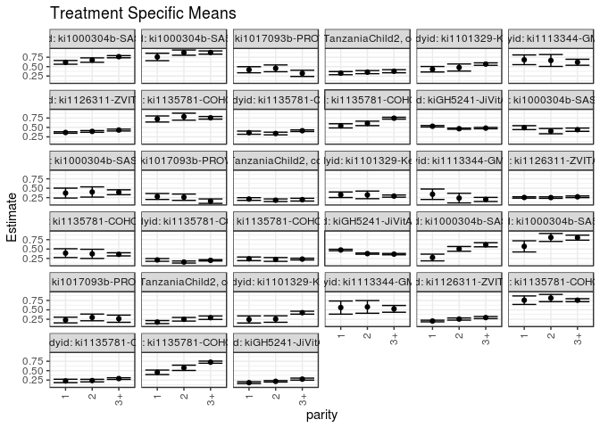

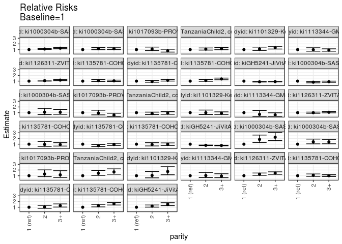

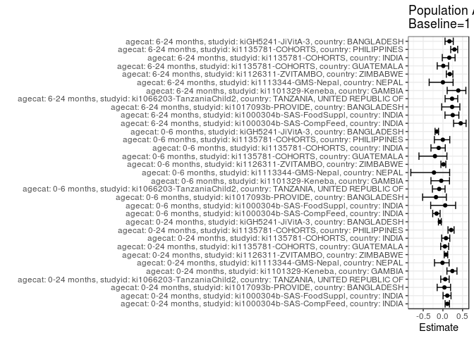

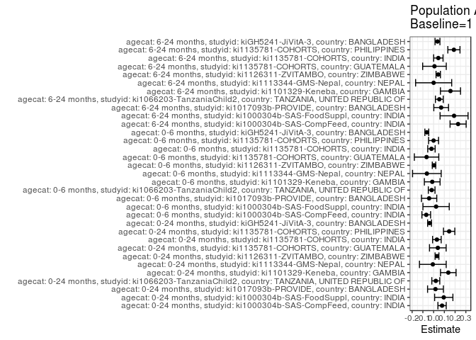

## Results Table

### Parameter: TSM

| agecat | studyid | country | intervention_level | baseline_level | estimate | ci_lower | ci_upper |
| --- | --- | --- | --- | --- | --- | --- | --- |
| 0-24 months | ki1000304b-SAS-CompFeed | INDIA | 1 | NA | 0.6129675 | 0.5632247 | 0.6627104 |
| 0-24 months | ki1000304b-SAS-CompFeed | INDIA | 2 | NA | 0.6742802 | 0.6156918 | 0.7328685 |
| 0-24 months | ki1000304b-SAS-CompFeed | INDIA | 3+ | NA | 0.7640580 | 0.7350607 | 0.7930552 |
| 0-24 months | ki1000304b-SAS-FoodSuppl | INDIA | 1 | NA | 0.7569704 | 0.6586394 | 0.8553014 |
| 0-24 months | ki1000304b-SAS-FoodSuppl | INDIA | 2 | NA | 0.8723758 | 0.8030181 | 0.9417336 |
| 0-24 months | ki1000304b-SAS-FoodSuppl | INDIA | 3+ | NA | 0.8744210 | 0.8314917 | 0.9173503 |
| 0-24 months | ki1017093b-PROVIDE | BANGLADESH | 1 | NA | 0.4169452 | 0.3356690 | 0.4982215 |
| 0-24 months | ki1017093b-PROVIDE | BANGLADESH | 2 | NA | 0.4548780 | 0.3645619 | 0.5451940 |
| 0-24 months | ki1017093b-PROVIDE | BANGLADESH | 3+ | NA | 0.3217156 | 0.2391176 | 0.4043136 |
| 0-24 months | ki1066203-TanzaniaChild2 | TANZANIA, UNITED REPUBLIC OF | 1 | NA | 0.3267117 | 0.2852139 | 0.3682095 |
| 0-24 months | ki1066203-TanzaniaChild2 | TANZANIA, UNITED REPUBLIC OF | 2 | NA | 0.3532772 | 0.3123037 | 0.3942506 |
| 0-24 months | ki1066203-TanzaniaChild2 | TANZANIA, UNITED REPUBLIC OF | 3+ | NA | 0.3778169 | 0.3368425 | 0.4187912 |
| 0-24 months | ki1101329-Keneba | GAMBIA | 1 | NA | 0.4307597 | 0.3574699 | 0.5040495 |
| 0-24 months | ki1101329-Keneba | GAMBIA | 2 | NA | 0.4760164 | 0.3820627 | 0.5699701 |
| 0-24 months | ki1101329-Keneba | GAMBIA | 3+ | NA | 0.5673353 | 0.5348687 | 0.5998019 |
| 0-24 months | ki1113344-GMS-Nepal | NEPAL | 1 | NA | 0.6817536 | 0.5525197 | 0.8109876 |
| 0-24 months | ki1113344-GMS-Nepal | NEPAL | 2 | NA | 0.6634157 | 0.5055115 | 0.8213198 |
| 0-24 months | ki1113344-GMS-Nepal | NEPAL | 3+ | NA | 0.6163620 | 0.5372407 | 0.6954834 |
| 0-24 months | ki1126311-ZVITAMBO | ZIMBABWE | 1 | NA | 0.3651592 | 0.3459394 | 0.3843791 |
| 0-24 months | ki1126311-ZVITAMBO | ZIMBABWE | 2 | NA | 0.3941129 | 0.3715962 | 0.4166296 |
| 0-24 months | ki1126311-ZVITAMBO | ZIMBABWE | 3+ | NA | 0.4301143 | 0.4057069 | 0.4545217 |
| 0-24 months | ki1135781-COHORTS | GUATEMALA | 1 | NA | 0.7247767 | 0.6442941 | 0.8052593 |
| 0-24 months | ki1135781-COHORTS | GUATEMALA | 2 | NA | 0.7858603 | 0.6929136 | 0.8788070 |
| 0-24 months | ki1135781-COHORTS | GUATEMALA | 3+ | NA | 0.7560802 | 0.7208512 | 0.7913092 |
| 0-24 months | ki1135781-COHORTS | INDIA | 1 | NA | 0.3607266 | 0.3186784 | 0.4027748 |
| 0-24 months | ki1135781-COHORTS | INDIA | 2 | NA | 0.3384419 | 0.3029381 | 0.3739457 |
| 0-24 months | ki1135781-COHORTS | INDIA | 3+ | NA | 0.4129501 | 0.3918824 | 0.4340179 |
| 0-24 months | ki1135781-COHORTS | PHILIPPINES | 1 | NA | 0.5417737 | 0.4860885 | 0.5974589 |
| 0-24 months | ki1135781-COHORTS | PHILIPPINES | 2 | NA | 0.6070919 | 0.5483099 | 0.6658739 |
| 0-24 months | ki1135781-COHORTS | PHILIPPINES | 3+ | NA | 0.7459805 | 0.7209785 | 0.7709826 |

[output cut: 69 more lines]

### Parameter: E(Y)

| agecat | studyid | country | intervention_level | baseline_level | estimate | ci_lower | ci_upper |
| --- | --- | --- | --- | --- | --- | --- | --- |
| 0-24 months | ki1000304b-SAS-CompFeed | INDIA | NA | NA | 0.6914547 | 0.6510509 | 0.7318584 |
| 0-24 months | ki1000304b-SAS-FoodSuppl | INDIA | NA | NA | 0.8513854 | 0.8163510 | 0.8864198 |
| 0-24 months | ki1017093b-PROVIDE | BANGLADESH | NA | NA | 0.4342857 | 0.3975409 | 0.4710305 |
| 0-24 months | ki1066203-TanzaniaChild2 | TANZANIA, UNITED REPUBLIC OF | NA | NA | 0.3470513 | 0.3278294 | 0.3662733 |
| 0-24 months | ki1101329-Keneba | GAMBIA | NA | NA | 0.5673367 | 0.5455633 | 0.5891101 |
| 0-24 months | ki1113344-GMS-Nepal | NEPAL | NA | NA | 0.6744186 | 0.6369554 | 0.7118819 |
| 0-24 months | ki1126311-ZVITAMBO | ZIMBABWE | NA | NA | 0.3966032 | 0.3885203 | 0.4046860 |
| 0-24 months | ki1135781-COHORTS | GUATEMALA | NA | NA | 0.7639706 | 0.7413939 | 0.7865473 |
| 0-24 months | ki1135781-COHORTS | INDIA | NA | NA | 0.3911447 | 0.3770865 | 0.4052029 |
| 0-24 months | ki1135781-COHORTS | PHILIPPINES | NA | NA | 0.6863963 | 0.6699497 | 0.7028430 |
| 0-24 months | kiGH5241-JiVitA-3 | BANGLADESH | NA | NA | 0.4938812 | 0.4860382 | 0.5017241 |
| 0-6 months | ki1000304b-SAS-CompFeed | INDIA | NA | NA | 0.4254902 | 0.3977202 | 0.4532601 |
| 0-6 months | ki1000304b-SAS-FoodSuppl | INDIA | NA | NA | 0.3939394 | 0.3457532 | 0.4421255 |
| 0-6 months | ki1017093b-PROVIDE | BANGLADESH | NA | NA | 0.2385714 | 0.2069753 | 0.2701675 |
| 0-6 months | ki1066203-TanzaniaChild2 | TANZANIA, UNITED REPUBLIC OF | NA | NA | 0.1947391 | 0.1787488 | 0.2107293 |
| 0-6 months | ki1101329-Keneba | GAMBIA | NA | NA | 0.3135456 | 0.2924164 | 0.3346748 |
| 0-6 months | ki1113344-GMS-Nepal | NEPAL | NA | NA | 0.2774086 | 0.2416141 | 0.3132032 |
| 0-6 months | ki1126311-ZVITAMBO | ZIMBABWE | NA | NA | 0.2580071 | 0.2507721 | 0.2652422 |
| 0-6 months | ki1135781-COHORTS | GUATEMALA | NA | NA | 0.3253896 | 0.2975756 | 0.3532035 |
| 0-6 months | ki1135781-COHORTS | INDIA | NA | NA | 0.1902526 | 0.1787489 | 0.2017563 |
| 0-6 months | ki1135781-COHORTS | PHILIPPINES | NA | NA | 0.2390451 | 0.2239262 | 0.2541640 |
| 0-6 months | kiGH5241-JiVitA-3 | BANGLADESH | NA | NA | 0.4108676 | 0.4034192 | 0.4183159 |
| 6-24 months | ki1000304b-SAS-CompFeed | INDIA | NA | NA | 0.5030750 | 0.4588491 | 0.5473009 |
| 6-24 months | ki1000304b-SAS-FoodSuppl | INDIA | NA | NA | 0.7615063 | 0.7073642 | 0.8156483 |
| 6-24 months | ki1017093b-PROVIDE | BANGLADESH | NA | NA | 0.2997812 | 0.2577294 | 0.3418330 |
| 6-24 months | ki1066203-TanzaniaChild2 | TANZANIA, UNITED REPUBLIC OF | NA | NA | 0.2276474 | 0.2069456 | 0.2483493 |
| 6-24 months | ki1101329-Keneba | GAMBIA | NA | NA | 0.4014652 | 0.3754511 | 0.4274793 |
| 6-24 months | ki1113344-GMS-Nepal | NEPAL | NA | NA | 0.5610329 | 0.5138522 | 0.6082135 |
| 6-24 months | ki1126311-ZVITAMBO | ZIMBABWE | NA | NA | 0.2458522 | 0.2363900 | 0.2553144 |
| 6-24 months | ki1135781-COHORTS | GUATEMALA | NA | NA | 0.7642458 | 0.7364214 | 0.7920702 |
| 6-24 months | ki1135781-COHORTS | INDIA | NA | NA | 0.2705750 | 0.2559548 | 0.2851951 |
| 6-24 months | ki1135781-COHORTS | PHILIPPINES | NA | NA | 0.6449788 | 0.6246093 | 0.6653483 |
| 6-24 months | kiGH5241-JiVitA-3 | BANGLADESH | NA | NA | 0.2172797 | 0.2079084 | 0.2266510 |

### Parameter: RR

| agecat | studyid | country | intervention_level | baseline_level | estimate | ci_lower | ci_upper |
| --- | --- | --- | --- | --- | --- | --- | --- |
| 0-24 months | ki1000304b-SAS-CompFeed | INDIA | 1 | 1 | 1.0000000 | 1.0000000 | 1.0000000 |
| 0-24 months | ki1000304b-SAS-CompFeed | INDIA | 2 | 1 | 1.1000259 | 1.0233123 | 1.1824904 |
| 0-24 months | ki1000304b-SAS-CompFeed | INDIA | 3+ | 1 | 1.2464901 | 1.1562703 | 1.3437495 |
| 0-24 months | ki1000304b-SAS-FoodSuppl | INDIA | 1 | 1 | 1.0000000 | 1.0000000 | 1.0000000 |
| 0-24 months | ki1000304b-SAS-FoodSuppl | INDIA | 2 | 1 | 1.1524570 | 0.9896087 | 1.3421033 |
| 0-24 months | ki1000304b-SAS-FoodSuppl | INDIA | 3+ | 1 | 1.1551588 | 1.0059808 | 1.3264585 |
| 0-24 months | ki1017093b-PROVIDE | BANGLADESH | 1 | 1 | 1.0000000 | 1.0000000 | 1.0000000 |
| 0-24 months | ki1017093b-PROVIDE | BANGLADESH | 2 | 1 | 1.0909777 | 0.8272540 | 1.4387750 |
| 0-24 months | ki1017093b-PROVIDE | BANGLADESH | 3+ | 1 | 0.7716015 | 0.5594059 | 1.0642879 |
| 0-24 months | ki1066203-TanzaniaChild2 | TANZANIA, UNITED REPUBLIC OF | 1 | 1 | 1.0000000 | 1.0000000 | 1.0000000 |
| 0-24 months | ki1066203-TanzaniaChild2 | TANZANIA, UNITED REPUBLIC OF | 2 | 1 | 1.0813117 | 0.9110476 | 1.2833961 |
| 0-24 months | ki1066203-TanzaniaChild2 | TANZANIA, UNITED REPUBLIC OF | 3+ | 1 | 1.1564229 | 0.9790555 | 1.3659225 |
| 0-24 months | ki1101329-Keneba | GAMBIA | 1 | 1 | 1.0000000 | 1.0000000 | 1.0000000 |
| 0-24 months | ki1101329-Keneba | GAMBIA | 2 | 1 | 1.1050624 | 0.8519040 | 1.4334515 |
| 0-24 months | ki1101329-Keneba | GAMBIA | 3+ | 1 | 1.3170574 | 1.1008835 | 1.5756800 |
| 0-24 months | ki1113344-GMS-Nepal | NEPAL | 1 | 1 | 1.0000000 | 1.0000000 | 1.0000000 |
| 0-24 months | ki1113344-GMS-Nepal | NEPAL | 2 | 1 | 0.9731017 | 0.7178625 | 1.3190924 |
| 0-24 months | ki1113344-GMS-Nepal | NEPAL | 3+ | 1 | 0.9040832 | 0.7191508 | 1.1365717 |
| 0-24 months | ki1126311-ZVITAMBO | ZIMBABWE | 1 | 1 | 1.0000000 | 1.0000000 | 1.0000000 |
| 0-24 months | ki1126311-ZVITAMBO | ZIMBABWE | 2 | 1 | 1.0792905 | 0.9988046 | 1.1662622 |
| 0-24 months | ki1126311-ZVITAMBO | ZIMBABWE | 3+ | 1 | 1.1778814 | 1.0903263 | 1.2724674 |
| 0-24 months | ki1135781-COHORTS | GUATEMALA | 1 | 1 | 1.0000000 | 1.0000000 | 1.0000000 |
| 0-24 months | ki1135781-COHORTS | GUATEMALA | 2 | 1 | 1.0842792 | 0.9224713 | 1.2744693 |
| 0-24 months | ki1135781-COHORTS | GUATEMALA | 3+ | 1 | 1.0431905 | 0.9256850 | 1.1756120 |
| 0-24 months | ki1135781-COHORTS | INDIA | 1 | 1 | 1.0000000 | 1.0000000 | 1.0000000 |
| 0-24 months | ki1135781-COHORTS | INDIA | 2 | 1 | 0.9382227 | 0.8023177 | 1.0971487 |
| 0-24 months | ki1135781-COHORTS | INDIA | 3+ | 1 | 1.1447731 | 1.0083940 | 1.2995966 |
| 0-24 months | ki1135781-COHORTS | PHILIPPINES | 1 | 1 | 1.0000000 | 1.0000000 | 1.0000000 |
| 0-24 months | ki1135781-COHORTS | PHILIPPINES | 2 | 1 | 1.1205636 | 0.9734398 | 1.2899235 |
| 0-24 months | ki1135781-COHORTS | PHILIPPINES | 3+ | 1 | 1.3769228 | 1.2360797 | 1.5338141 |

[output cut: 69 more lines]

### Parameter: PAR

| agecat | studyid | country | intervention_level | baseline_level | estimate | ci_lower | ci_upper |
| --- | --- | --- | --- | --- | --- | --- | --- |
| 0-24 months | ki1000304b-SAS-CompFeed | INDIA | 1 | NA | 0.0784871 | 0.0397484 | 0.1172258 |
| 0-24 months | ki1000304b-SAS-FoodSuppl | INDIA | 1 | NA | 0.0944150 | 0.0093712 | 0.1794587 |
| 0-24 months | ki1017093b-PROVIDE | BANGLADESH | 1 | NA | 0.0173405 | -0.0562805 | 0.0909615 |
| 0-24 months | ki1066203-TanzaniaChild2 | TANZANIA, UNITED REPUBLIC OF | 1 | NA | 0.0203396 | -0.0167378 | 0.0574171 |
| 0-24 months | ki1101329-Keneba | GAMBIA | 1 | NA | 0.1365770 | 0.0642114 | 0.2089426 |
| 0-24 months | ki1113344-GMS-Nepal | NEPAL | 1 | NA | -0.0073350 | -0.1317531 | 0.1170830 |
| 0-24 months | ki1126311-ZVITAMBO | ZIMBABWE | 1 | NA | 0.0314439 | 0.0138095 | 0.0490784 |
| 0-24 months | ki1135781-COHORTS | GUATEMALA | 1 | NA | 0.0391939 | -0.0382675 | 0.1166553 |
| 0-24 months | ki1135781-COHORTS | INDIA | 1 | NA | 0.0304181 | -0.0096208 | 0.0704569 |
| 0-24 months | ki1135781-COHORTS | PHILIPPINES | 1 | NA | 0.1446227 | 0.0917611 | 0.1974842 |
| 0-24 months | kiGH5241-JiVitA-3 | BANGLADESH | 1 | NA | -0.0377927 | -0.0557338 | -0.0198516 |
| 0-6 months | ki1000304b-SAS-CompFeed | INDIA | 1 | NA | -0.0686147 | -0.1090008 | -0.0282287 |
| 0-6 months | ki1000304b-SAS-FoodSuppl | INDIA | 1 | NA | 0.0229727 | -0.0995085 | 0.1454539 |
| 0-6 months | ki1017093b-PROVIDE | BANGLADESH | 1 | NA | -0.0418917 | -0.1130372 | 0.0292537 |
| 0-6 months | ki1066203-TanzaniaChild2 | TANZANIA, UNITED REPUBLIC OF | 1 | NA | -0.0183188 | -0.0494670 | 0.0128294 |
| 0-6 months | ki1101329-Keneba | GAMBIA | 1 | NA | -0.0130079 | -0.0860961 | 0.0600804 |
| 0-6 months | ki1113344-GMS-Nepal | NEPAL | 1 | NA | -0.0627640 | -0.1960056 | 0.0704775 |
| 0-6 months | ki1126311-ZVITAMBO | ZIMBABWE | 1 | NA | 0.0035904 | -0.0125432 | 0.0197240 |
| 0-6 months | ki1135781-COHORTS | GUATEMALA | 1 | NA | -0.0656249 | -0.1793724 | 0.0481227 |
| 0-6 months | ki1135781-COHORTS | INDIA | 1 | NA | -0.0203096 | -0.0546857 | 0.0140665 |
| 0-6 months | ki1135781-COHORTS | PHILIPPINES | 1 | NA | -0.0004303 | -0.0468830 | 0.0460223 |
| 0-6 months | kiGH5241-JiVitA-3 | BANGLADESH | 1 | NA | -0.0633540 | -0.0814503 | -0.0452576 |
| 6-24 months | ki1000304b-SAS-CompFeed | INDIA | 1 | NA | 0.2279586 | 0.1531061 | 0.3028112 |
| 6-24 months | ki1000304b-SAS-FoodSuppl | INDIA | 1 | NA | 0.1903847 | 0.0602067 | 0.3205626 |
| 6-24 months | ki1017093b-PROVIDE | BANGLADESH | 1 | NA | 0.0702299 | 0.0017352 | 0.1387246 |
| 6-24 months | ki1066203-TanzaniaChild2 | TANZANIA, UNITED REPUBLIC OF | 1 | NA | 0.0530717 | 0.0166785 | 0.0894650 |
| 6-24 months | ki1101329-Keneba | GAMBIA | 1 | NA | 0.1569047 | 0.0633343 | 0.2504752 |
| 6-24 months | ki1113344-GMS-Nepal | NEPAL | 1 | NA | 0.0002091 | -0.1677857 | 0.1682040 |
| 6-24 months | ki1126311-ZVITAMBO | ZIMBABWE | 1 | NA | 0.0429385 | 0.0225170 | 0.0633600 |
| 6-24 months | ki1135781-COHORTS | GUATEMALA | 1 | NA | 0.0078423 | -0.1019613 | 0.1176459 |
| 6-24 months | ki1135781-COHORTS | INDIA | 1 | NA | 0.0439155 | 0.0002183 | 0.0876128 |
| 6-24 months | ki1135781-COHORTS | PHILIPPINES | 1 | NA | 0.1888954 | 0.1323422 | 0.2454487 |
| 6-24 months | kiGH5241-JiVitA-3 | BANGLADESH | 1 | NA | 0.0359402 | 0.0131468 | 0.0587335 |

### Parameter: PAF

| agecat | studyid | country | intervention_level | baseline_level | estimate | ci_lower | ci_upper |
| --- | --- | --- | --- | --- | --- | --- | --- |
| 0-24 months | ki1000304b-SAS-CompFeed | INDIA | 1 | NA | 0.1135102 | 0.0567548 | 0.1668505 |
| 0-24 months | ki1000304b-SAS-FoodSuppl | INDIA | 1 | NA | 0.1108957 | 0.0040323 | 0.2062931 |
| 0-24 months | ki1017093b-PROVIDE | BANGLADESH | 1 | NA | 0.0399287 | -0.1453986 | 0.1952698 |
| 0-24 months | ki1066203-TanzaniaChild2 | TANZANIA, UNITED REPUBLIC OF | 1 | NA | 0.0586070 | -0.0545256 | 0.1596024 |
| 0-24 months | ki1101329-Keneba | GAMBIA | 1 | NA | 0.2407335 | 0.1026233 | 0.3575880 |
| 0-24 months | ki1113344-GMS-Nepal | NEPAL | 1 | NA | -0.0108761 | -0.2132796 | 0.1577618 |
| 0-24 months | ki1126311-ZVITAMBO | ZIMBABWE | 1 | NA | 0.0792831 | 0.0337385 | 0.1226810 |
| 0-24 months | ki1135781-COHORTS | GUATEMALA | 1 | NA | 0.0513029 | -0.0557038 | 0.1474633 |
| 0-24 months | ki1135781-COHORTS | INDIA | 1 | NA | 0.0777669 | -0.0304454 | 0.1746152 |
| 0-24 months | ki1135781-COHORTS | PHILIPPINES | 1 | NA | 0.2106985 | 0.1295057 | 0.2843182 |
| 0-24 months | kiGH5241-JiVitA-3 | BANGLADESH | 1 | NA | -0.0765219 | -0.1134890 | -0.0407820 |
| 0-6 months | ki1000304b-SAS-CompFeed | INDIA | 1 | NA | -0.1612605 | -0.2589230 | -0.0711742 |
| 0-6 months | ki1000304b-SAS-FoodSuppl | INDIA | 1 | NA | 0.0583152 | -0.3101535 | 0.3231554 |
| 0-6 months | ki1017093b-PROVIDE | BANGLADESH | 1 | NA | -0.1755941 | -0.5148998 | 0.0877142 |
| 0-6 months | ki1066203-TanzaniaChild2 | TANZANIA, UNITED REPUBLIC OF | 1 | NA | -0.0940686 | -0.2663169 | 0.0547499 |
| 0-6 months | ki1101329-Keneba | GAMBIA | 1 | NA | -0.0414864 | -0.3031145 | 0.1676143 |
| 0-6 months | ki1113344-GMS-Nepal | NEPAL | 1 | NA | -0.2262512 | -0.8145782 | 0.1713269 |
| 0-6 months | ki1126311-ZVITAMBO | ZIMBABWE | 1 | NA | 0.0139159 | -0.0506376 | 0.0745031 |
| 0-6 months | ki1135781-COHORTS | GUATEMALA | 1 | NA | -0.2016809 | -0.6080700 | 0.1020061 |
| 0-6 months | ki1135781-COHORTS | INDIA | 1 | NA | -0.1067507 | -0.3030904 | 0.0600061 |
| 0-6 months | ki1135781-COHORTS | PHILIPPINES | 1 | NA | -0.0018002 | -0.2162573 | 0.1748426 |
| 0-6 months | kiGH5241-JiVitA-3 | BANGLADESH | 1 | NA | -0.1541956 | -0.1991599 | -0.1109173 |
| 6-24 months | ki1000304b-SAS-CompFeed | INDIA | 1 | NA | 0.4531304 | 0.2721512 | 0.5891093 |
| 6-24 months | ki1000304b-SAS-FoodSuppl | INDIA | 1 | NA | 0.2500106 | 0.0533081 | 0.4058425 |
| 6-24 months | ki1017093b-PROVIDE | BANGLADESH | 1 | NA | 0.2342706 | -0.0301003 | 0.4307918 |
| 6-24 months | ki1066203-TanzaniaChild2 | TANZANIA, UNITED REPUBLIC OF | 1 | NA | 0.2331313 | 0.0565089 | 0.3766899 |
| 6-24 months | ki1101329-Keneba | GAMBIA | 1 | NA | 0.3908302 | 0.1088822 | 0.5835704 |
| 6-24 months | ki1113344-GMS-Nepal | NEPAL | 1 | NA | 0.0003728 | -0.3487490 | 0.2591249 |
| 6-24 months | ki1126311-ZVITAMBO | ZIMBABWE | 1 | NA | 0.1746517 | 0.0874236 | 0.2535422 |
| 6-24 months | ki1135781-COHORTS | GUATEMALA | 1 | NA | 0.0102615 | -0.1443634 | 0.1439937 |
| 6-24 months | ki1135781-COHORTS | INDIA | 1 | NA | 0.1623045 | -0.0156225 | 0.3090605 |
| 6-24 months | ki1135781-COHORTS | PHILIPPINES | 1 | NA | 0.2928708 | 0.1991004 | 0.3756623 |
| 6-24 months | kiGH5241-JiVitA-3 | BANGLADESH | 1 | NA | 0.1654096 | 0.0540939 | 0.2636255 |